# Geographical Location and Internet Quality of Life

by Workshop Group 31/1

GitHub link: https://github.com/ryxh7464/final-project

## Research Question

Our research question is the following: “Do geographical location and characteristics affect internet quality of life in the UK?”.

Internet quality of life is becoming more important than ever - especially with how increasingly online our world is becoming. We aim to examine the relationships between geographical location of UK internet users (and related metrics such as household income) and metrics which can help us gain a picture of internet quality of life, such as download speed. We will also consider how things have changed over the course of two months in 2019.

## Data

For our project we used 3 datasets in total, 2 from data.gov.ukm, and one from ons.gov.uk. The first two datasets concern fixed line broadband speeds in the UK in February and August 2019, respectively. Both datasets come from Ofcom, the UK’s communications regulator. The broadband data was collected from a sample of customers who had speed monitoring equipment stored in their homes.

The third dataset contains information on the GDHI (Gross Disposable Household Income) for UK constituent countries and regions.

For this project, we will be mainly focusing on 24hr average download speed, Urban/Rural (whether or not a reading comes from an urban or rural location) and GDHI per head.

## Findings

### Initial data visualisation using choropleth maps

To explore regional variations and identify any obvious trends or correlations, we created choropleth maps of the average 24 hour download speed in February and August, the GDHI, and the ratio between average download speed in urban and rural areas, for each region. These maps could then be compared to each other, to see if speeds had changed over time and if there were similarities in the spatial trends of different variables, and then these relationships could be investigated further in the models.

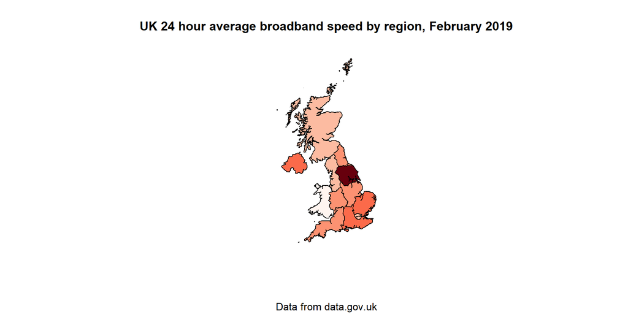

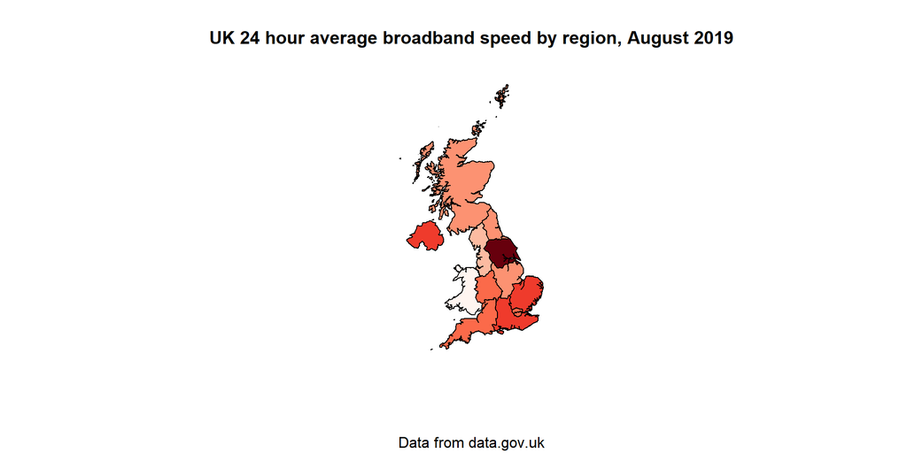

These two maps both suggest a similar trend in average speeds - they seem to be higher on average in the south, but the highest speed is found in Yorkshire in both despite low speeds in surrounding regions, and the lowest is in Wales. This pattern does not change significantly from February to August, although some speeds appear to increase slightly.

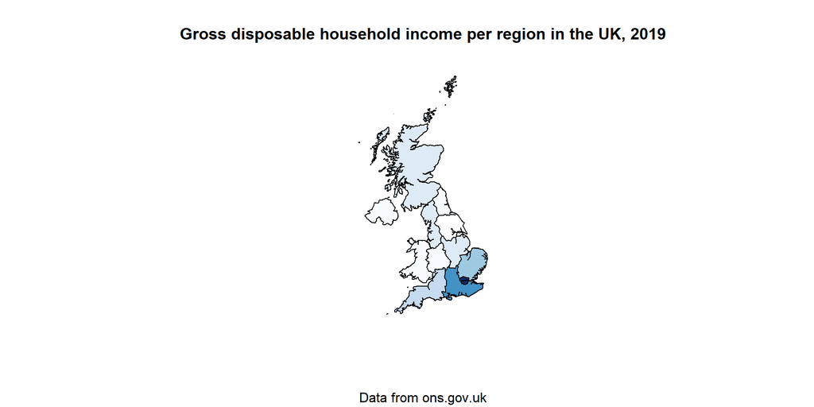

Comparing the GDHI map to the average download speed maps, we see that, while both have areas of higher values in the south, regions such as Yorkshire and Northern Ireland have high average speeds despite their comparatively low GDHI, suggesting that this relationship is more complex and there may be other variables involved.

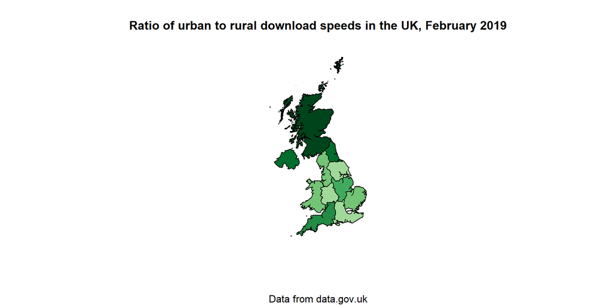

### The impact of GDHI and urban/rural location on internet quality

We plotted the following linear regression models using GDHI as a single predictor for 24 hour download speed, packet loss and Netflix start up delay:

```
## # A tibble: 2 × 5
##   term          estimate std.error statistic      p.value
##   <chr>            <dbl>     <dbl>     <dbl>        <dbl>
## 1 (Intercept)   42.0      7.83          5.36 0.0000000881
## 2 gdhi_per_head  0.00130  0.000369      3.52 0.000435
```

```
## # A tibble: 2 × 5
##   term          estimate    std.error statistic   p.value
##   <chr>            <dbl>        <dbl>     <dbl>     <dbl>
## 1 (Intercept)    1.30e-3 0.000325         3.99  0.0000672
## 2 gdhi_per_head -8.47e-9 0.0000000153    -0.553 0.580
```

```
## # A tibble: 2 × 5
##   term           estimate std.error statistic  p.value
##   <chr>             <dbl>     <dbl>     <dbl>    <dbl>
## 1 (Intercept)   1373.      73.9         18.6  9.54e-74
## 2 gdhi_per_head   -0.0128   0.00347     -3.68 2.37e- 4
```

Here we see that increased GDHI is linked to increased IQOL, with the model estimating that households with higher GDHI per head will have higher download speeds, less packet loss and lower Netflix start up delays. Note that the coefficients are comparatively small - in context, an average household in Yorkshire & Humber would have an estimated 24hr download speed of approximately 65.3Mbps, compared to a household in London for which we could estimate a speed of 81.3Mbps (they have GDHI per head values of £17959 and £30256 respectively according to the dataset).

Next we looked at predicting 24 hour download speed from Urban/Rural:

```
## # A tibble: 2 × 5
##   term             estimate std.error statistic   p.value
##   <chr>               <dbl>     <dbl>     <dbl>     <dbl>
## 1 (Intercept)          44.1      2.00      22.0 1.34e-101
## 2 urban_ruralUrban     44.3      2.50      17.7 1.32e- 67
```

We can compare this to see how this has changed from February to August:

```
## # A tibble: 2 × 5
##   term             estimate std.error statistic  p.value
##   <chr>               <dbl>     <dbl>     <dbl>    <dbl>
## 1 (Intercept)          43.2      2.72      15.9 5.81e-54
## 2 urban_ruralUrban     43.1      3.40      12.7 1.28e-35
```

```
## # A tibble: 2 × 5
##   term             estimate std.error statistic  p.value
##   <chr>               <dbl>     <dbl>     <dbl>    <dbl>
## 1 (Intercept)          45.0      2.96      15.2 1.60e-49
## 2 urban_ruralUrban     45.7      3.70      12.3 9.24e-34
```

Here we see that on average, households in rural locations are worse off in terms of broadband speed - with urban locations having speeds around twice as fast as rural households (not taking into account region or income, etc.).

We can also try predicting packet loss and Netflix start up delay from the Urban/Rural variable as well for both years combined:

```
## # A tibble: 2 × 5
##   term               estimate std.error statistic  p.value
##   <chr>                 <dbl>     <dbl>     <dbl>    <dbl>
## 1 (Intercept)       0.00114   0.0000809    14.1   3.36e-44
## 2 urban_ruralUrban -0.0000563 0.000101     -0.557 5.78e- 1
```

```
## # A tibble: 2 × 5
##   term             estimate std.error statistic  p.value
##   <chr>               <dbl>     <dbl>     <dbl>    <dbl>
## 1 (Intercept)         1311.      18.1      72.6 0
## 2 urban_ruralUrban    -364.      22.4     -16.3 7.73e-58
```

This data supports the idea that Urban households have better internet quality of life - on average they have lower packet loss and startup delays (not taking into account location / GDHI, etc.)

Finally we decided to see if we could predict 24hr download speed based off of the variables of GDHI per head and Urban/Rural. The data was split with 75% of observations in the training set, and 25% in the testing set. We can see a snapshot of the predictions below, compared to the actual values:

```
## ══ Workflow [trained] ══════════════════════════════════════════════════════════
## Preprocessor: Recipe
## Model: linear_reg()
##
## ── Preprocessor ────────────────────────────────────────────────────────────────
## 1 Recipe Step
##
## • step_dummy()
##
## ── Model ───────────────────────────────────────────────────────────────────────
##
## Call:
## stats::lm(formula = ..y ~ ., data = data)
##
## Coefficients:
##       (Intercept)      gdhi_per_head  urban_rural_Urban
##         3.915e+01          1.673e-04          4.264e+01
```

```
## # A tibble: 1,043 × 4
##    .pred x24_hr_average_download_speed urban_rural gdhi_per_head
##    <dbl>                         <dbl> <chr>               <dbl>
##  1  84.7                         72.8  Urban               17331
##  2  84.7                         40.0  Urban               17331
##  3  86.8                         16.9  Urban               30256
##  4  NA                          217.   Urban                  NA
##  5  42.3                         70.9  Rural               18635
##  6  42.0                         58.2  Rural               17331
##  7  42.7                         69.7  Rural               21222
##  8  42.0                          2.51 Rural               17263
##  9  NA                           17.2  Urban                  NA
## 10  86.8                         36.5  Urban               30256
## # … with 1,033 more rows
```

We can also see the adjusted R squared value for the model below:

```
## [1] 0.07540938
```

Here we get a value of 7.5%, which is quite low, suggesting that the model is not very good at predicting average download speed, as it does a poor job of predicting the test data.

### The impact of distance from exchange on internet quality

As part of geographic location, distance from exchange is also an important factor affecting internet quality. We have used linear regression to analyze the extent to which average download speed, jitter, latency and packet loss are affected by distance from exchange.

These parameters are valuable to study as they affect many aspects of network life, such as latency affecting the gaming experience, average download speed and packet loss affecting load time, and jitter affecting call quality.

The following are linear regression models for the various parameters and distance from exchange in February and August, respectively.

```
## # A tibble: 2 × 5
##   term                   estimate std.error statistic  p.value
##   <chr>                     <dbl>     <dbl>     <dbl>    <dbl>
## 1 (Intercept)            88.1       5.51        16.0  1.17e-17
## 2 distance_from_exchange -0.00634   0.00223     -2.84 7.43e- 3
```

```
## # A tibble: 2 × 5
##   term                   estimate std.error statistic  p.value
##   <chr>                     <dbl>     <dbl>     <dbl>    <dbl>
## 1 (Intercept)            84.4       5.16        16.4  1.09e-17
## 2 distance_from_exchange -0.00459   0.00231     -1.99 5.47e- 2
```

```
## # A tibble: 2 × 5
##   term                   estimate std.error statistic  p.value
##   <chr>                     <dbl>     <dbl>     <dbl>    <dbl>
## 1 (Intercept)            13.0      0.856        15.2  5.58e-17
## 2 distance_from_exchange  0.00112  0.000346      3.24 2.65e- 3
```

```
## # A tibble: 2 × 5
##   term                    estimate std.error statistic  p.value
##   <chr>                      <dbl>     <dbl>     <dbl>    <dbl>
## 1 (Intercept)            14.3       0.394        36.3  9.02e-29
## 2 distance_from_exchange  0.000376  0.000176      2.13 4.02e- 2
```

```
## # A tibble: 2 × 5
##   term                      estimate    std.error statistic  p.value
##   <chr>                        <dbl>        <dbl>     <dbl>    <dbl>
## 1 (Intercept)            0.000727    0.000191          3.81 0.000542
## 2 distance_from_exchange 0.000000145 0.0000000772      1.88 0.0689
```

```
## # A tibble: 2 × 5
##   term                       estimate    std.error statistic     p.value
##   <chr>                         <dbl>        <dbl>     <dbl>       <dbl>
## 1 (Intercept)            0.00106      0.000170         6.25  0.000000403
## 2 distance_from_exchange 0.0000000505 0.0000000761     0.663 0.512
```

Based on these linear regressions, it can be concluded that average download speed and distance from exchange are negatively correlated, and latency and packet loss are positively correlated with distance from exchange. In February, for every 1000m increase in distance from exchange, on average, the average download speed will decrease by 6.3Mbps, the latency will increase by 1.1ms and the packet loss rate will increase by 0.014%. In August, for every 1000m increase in distance from exchange, on average, the average download speed will decrease by 4.6Mbps, the latency will increase by 0.38ms and the packet loss rate will increase by 0.005%.

```
## # A tibble: 2 × 5
##   term                     estimate std.error statistic  p.value
##   <chr>                       <dbl>     <dbl>     <dbl>    <dbl>
## 1 (Intercept)             0.765     0.0723       10.6   1.88e-12
## 2 distance_from_exchange -0.0000180 0.0000292    -0.616 5.42e- 1
```

```
## # A tibble: 2 × 5
##   term                     estimate std.error statistic    p.value
##   <chr>                       <dbl>     <dbl>     <dbl>      <dbl>
## 1 (Intercept)            0.751      0.143        5.24   0.00000837
## 2 distance_from_exchange 0.00000504 0.0000641    0.0786 0.938
```

```
## # A tibble: 2 × 5
##   term                    estimate std.error statistic  p.value
##   <chr>                      <dbl>     <dbl>     <dbl>    <dbl>
## 1 (Intercept)            0.327     0.0258        12.7  1.20e-14
## 2 distance_from_exchange 0.0000350 0.0000104      3.36 1.91e- 3
```

```
## # A tibble: 2 × 5
##   term                     estimate  std.error statistic  p.value
##   <chr>                       <dbl>      <dbl>     <dbl>    <dbl>
## 1 (Intercept)            0.361      0.0137        26.3   3.71e-24
## 2 distance_from_exchange 0.00000473 0.00000615     0.770 4.46e- 1
```

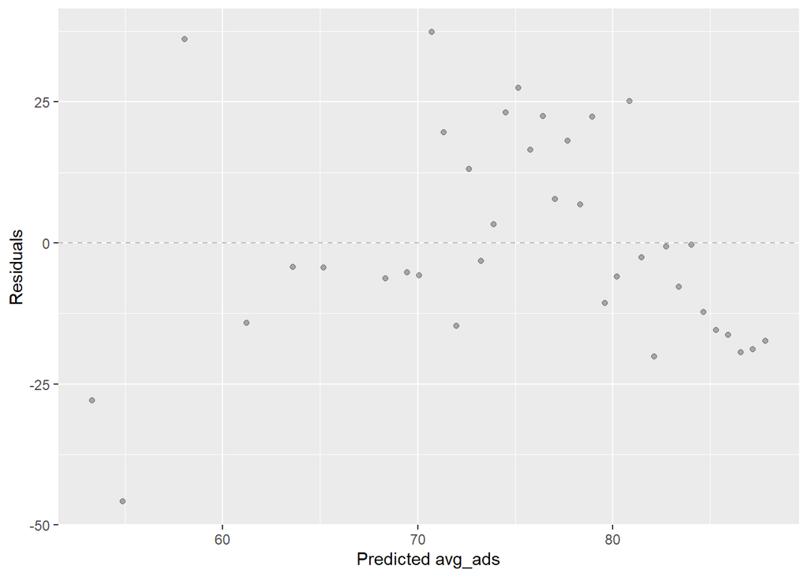

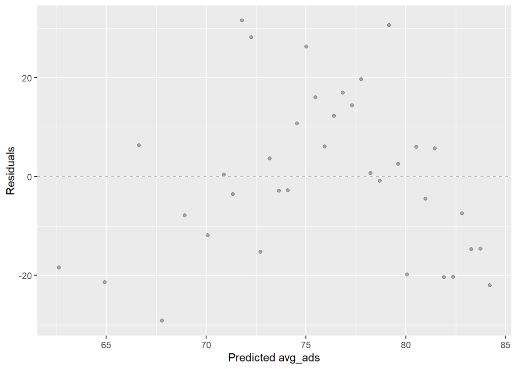

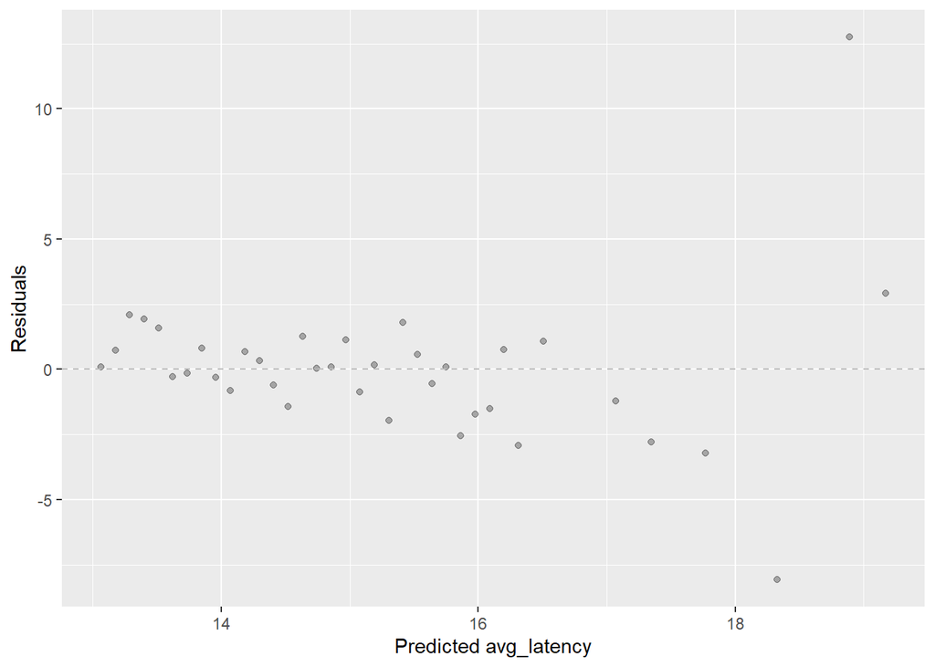

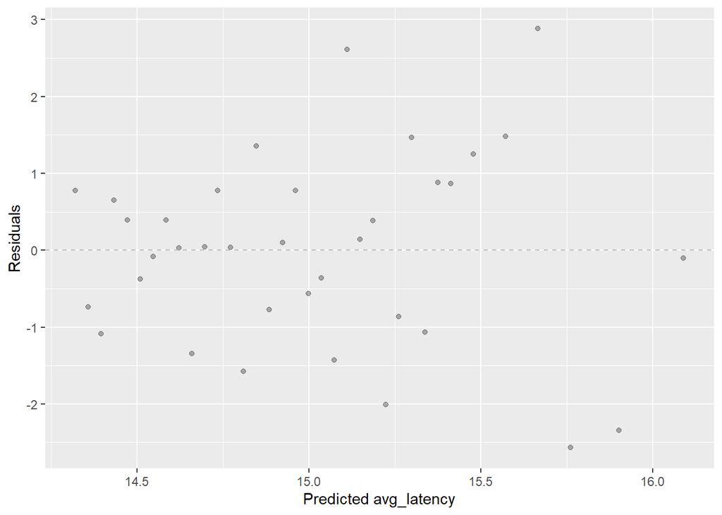

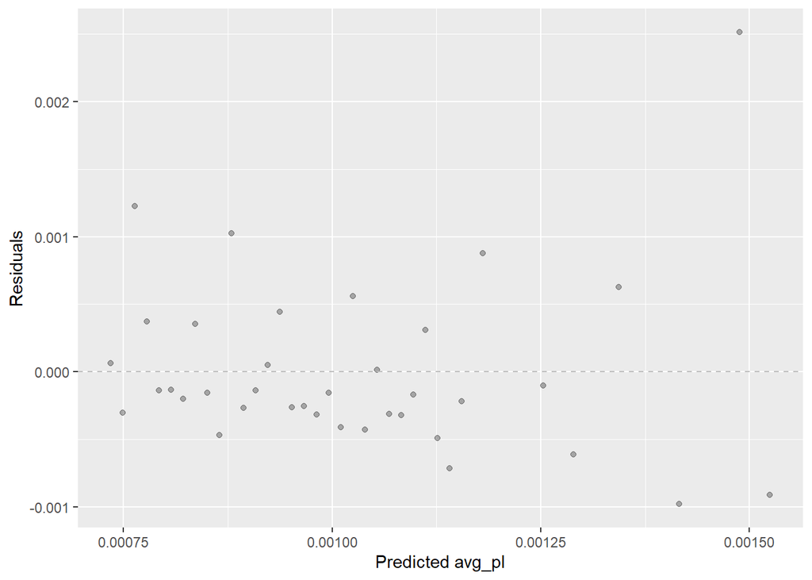

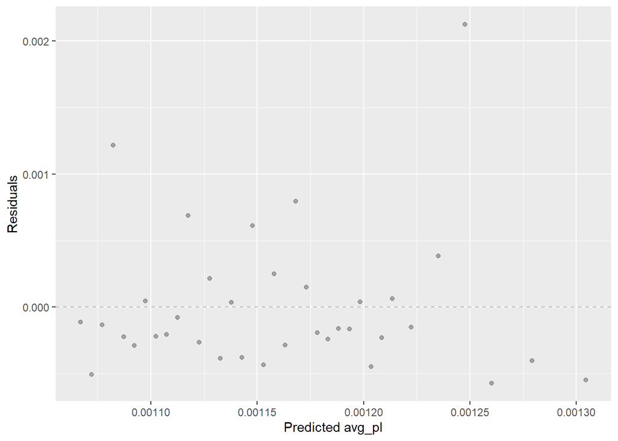

According to the following code, in 2019, the average download speed, latency and packet loss all greatly affect page load time. On average, every 1Mbps increase in download speed decreases load time by 0.0017 seconds, every 1ms increase in latency increases load time by 0.037 seconds, and every 1% increase in packet loss increases load time by 0.29 seconds. These three parameters are all influenced by distance from exchange. It can be further concluded that distance from exchange indirectly affects the internet quality of life, such as page load time.

```
## # A tibble: 4 × 5
##   term                          estimate std.error statistic  p.value
##   <chr>                            <dbl>     <dbl>     <dbl>    <dbl>
## 1 (Intercept)                    5.00     0.0189       264.  0
## 2 x24_hr_average_download_speed -0.00167  0.000112     -15.0 2.67e-49
## 3 x24_hour_latency               0.0372   0.000841      44.2 0
## 4 x24_hour_packet_loss          28.9      2.86          10.1 1.03e-23
```

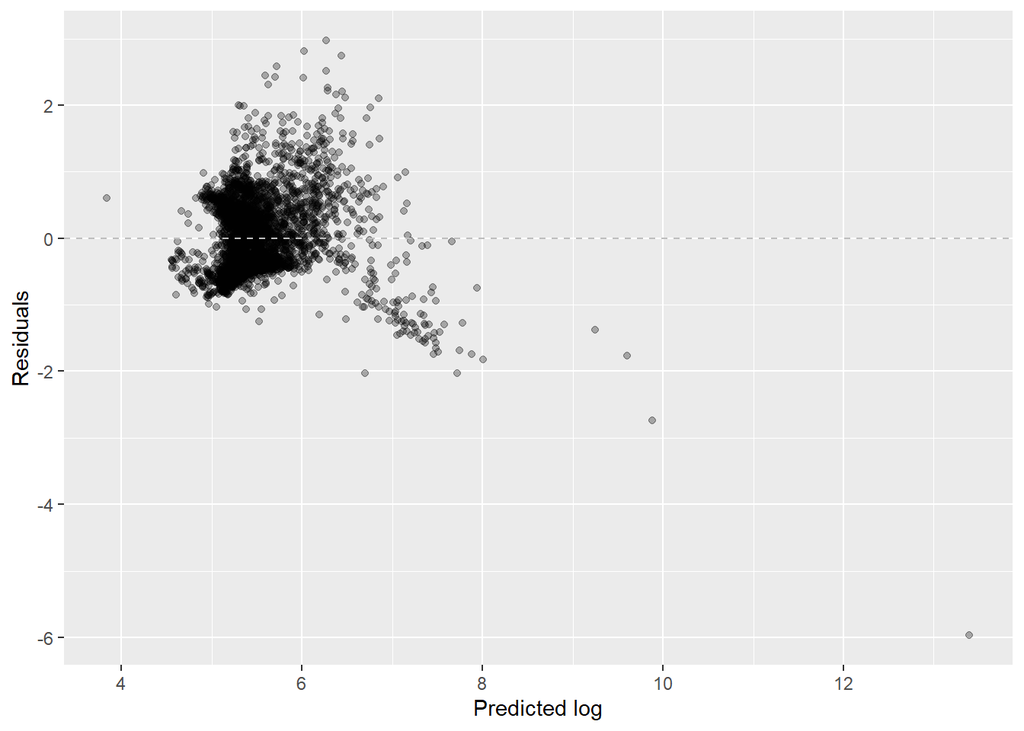

### Graphs of internet quality factors against variables effect

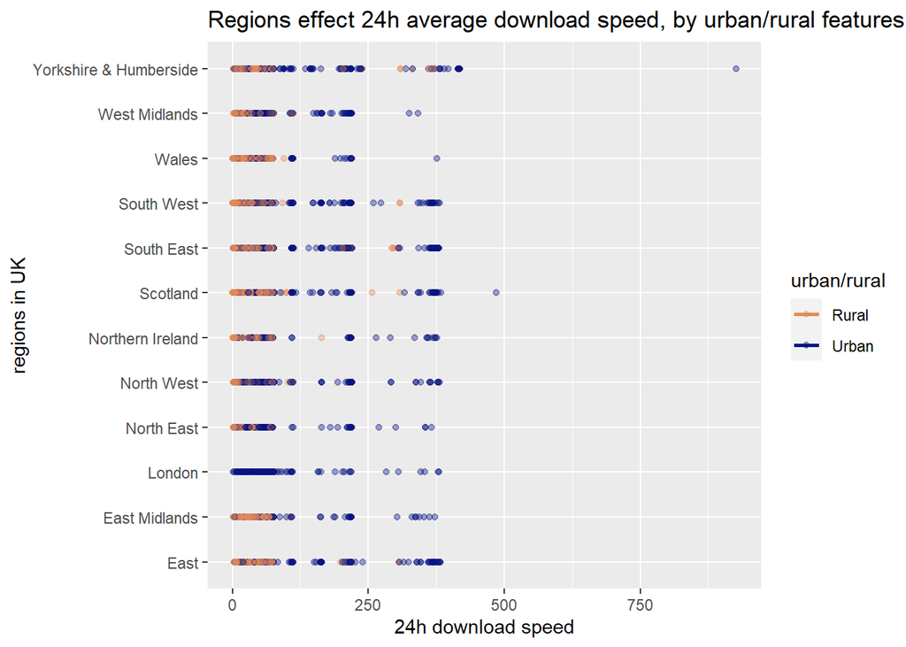

[figure not shown]

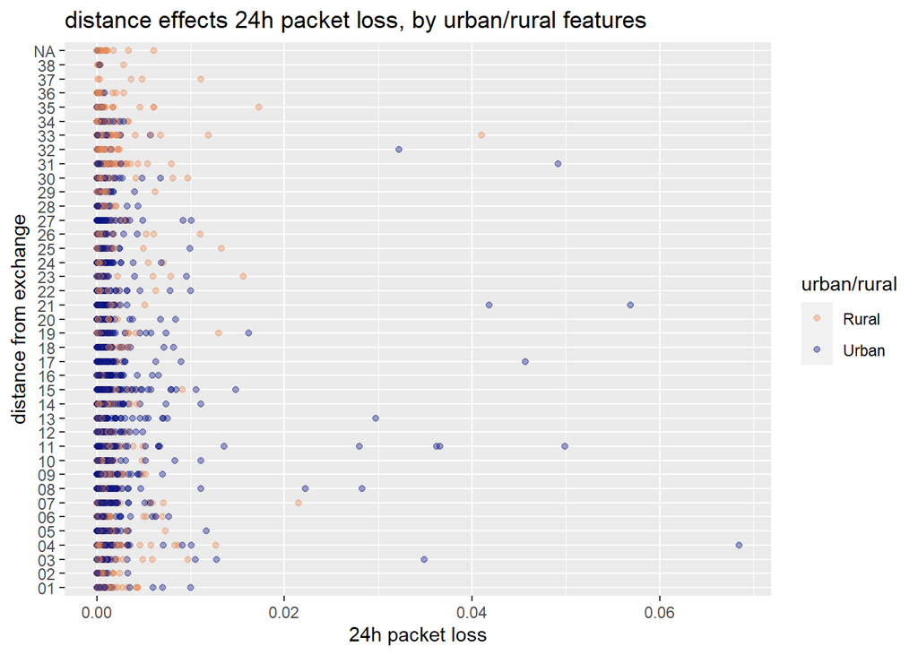

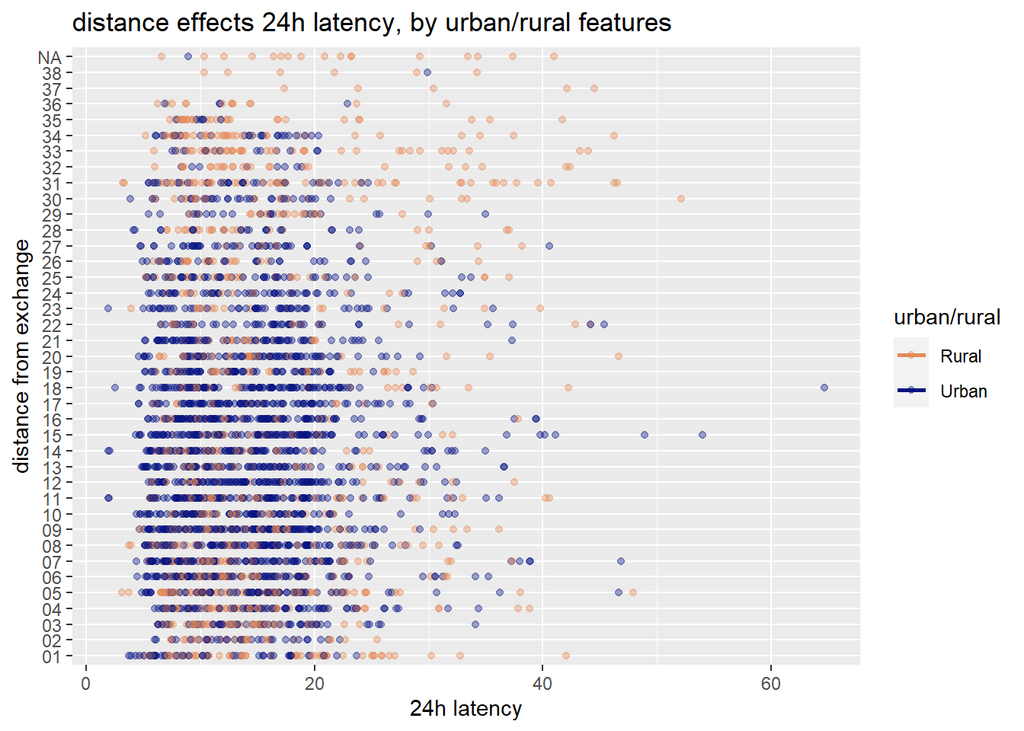

We assume that internet quality can be defined by average download speed, packet loss and latency on the internet in 24 hours. And they are influenced by geolocations that whether users are in an urban or rural are as well, their UK region and distance from exchange. We can see from the graphs that in rural areas, users generally experienced lower download speed, higher packet loss and higher latency. Also, for distance from exchange, since the category names are too long to be used and would cause disordered y-axis, I gave them simpler names.

### Limitations of project

One of the key limitations of our data was the fact that GDHI was given only by region. This made it difficult to compare households in the same areas with different incomes - i.e. high income vs low income rural households. As a result we could not see whether different incomes in areas affected customers’ broadband speed.

Additionally, it was difficult to add keys to the choropleth maps as base R was used for the plotting. With more time it would be useful to have a key on the maps. However, the key is not essential here because the maps were only used to visually compare trends, not to determine specific values.

## Presentation

Our presentation.

## References

### Data sources:

2020, Fixed broadband speeds (February 2019 data), Ofcom, viewed Nov 16th 2022, https://www.data.gov.uk/dataset/dfe843da-06ca-4680-9ba0-fbb27319e402/uk-fixed-line-broadband-performance

2020, Fixed broadband speeds (August 2019 data), Ofcom, viewed Nov 16th 2022, https://www.data.gov.uk/dataset/dfe843da-06ca-4680-9ba0-fbb27319e402/uk-fixed-line-broadband-performance

2021, Regional gross disposable household income, UK: 1997 to 2019, viewed Nov 16th 2022, https://www.ons.gov.uk/economy/regionalaccounts/grossdisposablehouseholdincome/bulletins/regionalgrossdisposablehouseholdincomegdhi/1997to2019

### References for maps:

https://www.r-graph-gallery.com

https://www.kaggle.com/datasets/dorianlazar/uk-regions-geojson

https://cran.r-project.org/web/packages/geojsonio/geojsonio.pdf

https://www.rdocumentation.org/packages/graphics/versions/3.6.2/topics/plot

https://rdrr.io/cran/tigris/man/geo_join.html

### References for linear modelling:

https://www.forcepoint.com/cyber-edu/packet-loss

https://www.finder.com/uk/tv-streaming-statistics